# The Impact of Technology Access on Earnigs

Group 06

January 28, 2019

# 0. Research Question and Variable Selection

**Research Questions:**

With a past of racial inequality in the southern states it would be interesting to examine how race/ethnicity is related to access to the internet and other technologies and how not having or having access could effect a persons earnings. This can be explored via the following research questions:

1. In the state of Alabama, how to earnings vary by access to the internet/technology?
2. Does the internet/technology premium vary by race and ethnicity?

**Variable Selection**:

To answer the research questions, this study looks at the variables which will reveal the demographic characteristics - such as “age” or “race”; socioeconomic status - such as “employment status” or “wage”; and the access to techonlogy - such as “access to internet.”

- The following variables will be included in this study. (Some other varialbes will be used as connector when joining tables but will not be included in the final dataframe.)
1. AGEP # Age: 0#99
2. SEMP # Self-employment income past 12 months (signed)
3. WAGP # Wages or salary income past 12 months
4. HISP # Recoded detailed Hispanic origin
5. NATIVITY # Nativity
6. PERNP # Total person’s earnings
7. RAC1P # Recoded detailed race code
8. RACAIAN # American Indian and Alaska Native recode
9. RACASN # Asian recode
10. RACBLK # Black or African American recode
11. RACNH # Native Hawaiian recode
12. RACWHT # White recode
13. SCHL # Educational attainment
14. WAOB # World area of birth
15. WKW #Weeks worked during past 12 months
16. ACCESS # Access to the Internet

# 1. System Setup

The following chunk of code (hidden from this html file) are applied to clean the working environment. There libraries and one external function are loaded.

Three loaded libraries are:

1. tidyverse
2. here
3. DataExplorer

One external function was programmed by the team. It is located at folder of “code”, and the function is:

1. function_convert_CSV_to_vector.R

# 2. Data Cleaning

## 2.1 Import the raw data

Import the raw data of personal income (ss16pal) into the dataframe of “base.”

Import the household level information (ss16hal) about internet access and merge the data into “base.”

## 2.2 Structure of raw data

Based on the first observation below, some ordinary data will be converted into numerical type, and some categorical data will be converted into factor type.

```
## Classes 'spec_tbl_df', 'tbl_df', 'tbl' and 'data.frame': 47659 obs. of  17 variables:
##  $ AGEP    : chr  "84" "84" "78" "46" ...
##  $ SEMP    : chr  "0000000" "0000000" "0000000" "0000000" ...
##  $ WAGP    : chr  "0000000" "0000000" "0027300" "0065000" ...
##  $ HISP    : chr  "01" "01" "01" "01" ...
##  $ NATIVITY: num  1 1 1 1 1 1 1 1 1 1 ...
##  $ PERNP   : chr  "000000000" "000000000" "000027300" "000065000" ...
##  $ RAC1P   : num  1 1 1 1 1 1 1 1 1 1 ...
##  $ RACAIAN : num  0 0 0 0 0 0 0 0 0 0 ...
##  $ RACASN  : num  0 0 0 0 0 0 0 0 0 0 ...
##  $ RACBLK  : num  0 0 0 0 0 0 0 0 0 0 ...
##  $ RACNH   : num  0 0 0 0 0 0 0 0 0 0 ...
##  $ RACWHT  : num  1 1 1 1 1 1 1 1 1 1 ...
##  $ SCHL    : chr  "19" "21" "19" "20" ...
##  $ SEX     : num  2 1 2 1 2 1 2 2 1 1 ...
##  $ WAOB    : num  1 1 1 1 1 1 1 1 1 1 ...
##  $ WKW     : num  NA NA 1 1 NA NA NA NA NA 1 ...
##  $ ACCESS  : num  1 1 3 1 1 1 1 1 1 1 ...
```

## 2.3 Convert the variable types

Convert the categorical data into factor type and numetical data into numeric type. The factorial data in this dataframe will keep its representative code instead of the category name to save the memory space.

Replace the factor levels to the contents in the survery question for easy understanding.

==================

# 3. Criteria for filtering the data

**1. Age range:**

The ages of cases covered in the survey are ranging from **0 year old to 93 years old**. There is **no missing value** under the age category.

According to the regulation from US Department of Labor, the legal working age is 14 (for most non-agricultural work), and the early retirement age is 62. This study will looks at the **age group of 14~62 years old (Data Filtering Criteria 1)**.

```r
base <- base %>%
        mutate( age_group = case_when(
                            AGEP < 14 ~ "Other ages (exclude)",
                            AGEP >= 14 & AGEP <= 62 ~ "Age 14-62 (include)",
                            AGEP > 62 ~ "Other ages (exclude)"
        ))
base$age_group <- as.factor(base$age_group)
```

Remove the records which are out of the age group of 14 to 62.

```r
base <- base %>%  filter(AGEP>=14 & AGEP <= 62)
base$age_group <- NULL
```

**2. Earnings:**

In this study we will consider everyone that had positive earnings in the last 12 months.

```r
base <- base %>%  filter(WAGP > 0)
```

**3. Annually Working Weeks:**

The selection of full time employee is arbitrary. This study includes groups which **work more than 40 weeks a years (Data Filtering Criteria 4)**. (Please be noted: More studies shold be considered in decideing the threshold separating full-time and part-time employee. This study set the 40 week/year as the threshold for now.)

```r
base <- base %>%
         filter(WKW %in% c("50 to 52 weeks worked during past 12 months", "48 to 49 weeks worked during past 12 months", "40 to 47 weeks worked during past 12 months"))
```

==================

# 4. Building Models

## 4.1 Examine access to the internet and its relation to earnings.

```r
base %>% select(ACCESS) %>% summary()
```

```
##          ACCESS
##  Paid Access:13711
##  Free Access:  372
##  No Access  : 1268
##  NA's       :  254
```

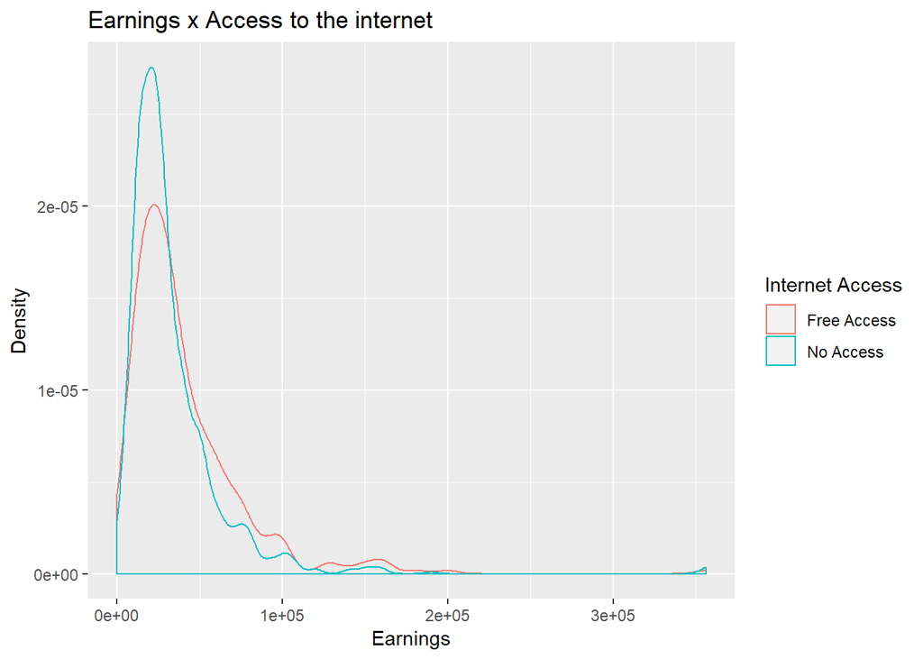

```r
base %>%  filter(!is.na(ACCESS) & ACCESS != "Paid Access") %>%
  ggplot(aes(WAGP,color=ACCESS)) + geom_density() +
  labs(title="Earnings x Access to the internet",
       x ="Earnings", y = "Density") +
  scale_color_discrete(name="Internet Access",
                      labels=c("Free Access", "No Access"))
```

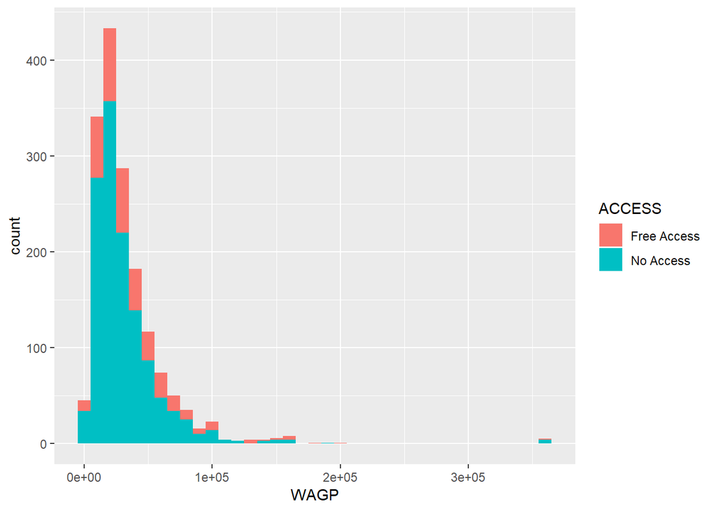

```r
base %>%  filter(!is.na(ACCESS) & ACCESS != "Paid Access") %>%
  ggplot() + geom_histogram(aes(x=WAGP,fill=ACCESS), binwidth = 10000)
```

```r
base %>%
  filter(!is.na(ACCESS) & ACCESS != "Paid Access") %>%
  group_by(ACCESS, RAC1P) %>%
  summarise (mean(WAGP),sd(WAGP),min(WAGP),max(WAGP), median(WAGP))
```

| ACCESS | RAC1P | mean(WAGP) | sd(WAGP) | min(WAGP) | max(WAGP) | median(WAGP) |
| --- | --- | --- | --- | --- | --- | --- |
| Free Access | White | 42556.80 | 38338.475 | 1600 | 356000 | 32000 |
| Free Access | African American | 35958.26 | 28824.551 | 2800 | 160000 | 27000 |
| Free Access | American Indian | 18800.00 | NaN | 18800 | 18800 | 18800 |
| Free Access | Others | 42333.33 | 27319.102 | 12000 | 65000 | 50000 |
| Free Access | Two more | 13666.67 | 1527.525 | 12000 | 15000 | 14000 |
| No Access | White | 35403.61 | 31349.677 | 100 | 356000 | 28000 |
| No Access | African American | 29102.78 | 28531.366 | 1000 | 356000 | 22000 |
| No Access | American Indian | 19125.00 | 8451.183 | 6700 | 25000 | 22400 |
| No Access | Tribes or Others | 20000.00 | NaN | 20000 | 20000 | 20000 |
| No Access | Asian | 28500.00 | 12020.815 | 20000 | 37000 | 28500 |

[output cut: 2 more lines]

**Building the model**

```r
base_model <- base %>%
  filter(!is.na(ACCESS) & ACCESS != "Paid Access") %>%
  mutate(free_access = ACCESS == "Free Access",
         hispanic = HISP != "Not Spanish/Hispanic/Latino",
         black = RACBLK == "Yes",
         female = SEX =="Female"
         )
model_01 <- lm(WAGP ~ free_access, data = base_model)

model_01 %>% summary()
```

```
##
## Call:
## lm(formula = WAGP ~ free_access, data = base_model)
##
## Residuals:
##    Min     1Q Median     3Q    Max
## -38618 -17565  -7565   7435 323435
##
## Coefficients:
##                 Estimate Std. Error t value Pr(>|t|)
## (Intercept)      32564.9      880.2  36.999  < 2e-16 ***
## free_accessTRUE   7653.4     1848.0   4.141 3.63e-05 ***
## ---
## Signif. codes:  0 '***' 0.001 '**' 0.01 '*' 0.05 '.' 0.1 ' ' 1
##
## Residual standard error: 31340 on 1638 degrees of freedom
## Multiple R-squared:  0.01036,    Adjusted R-squared:  0.009758
## F-statistic: 17.15 on 1 and 1638 DF,  p-value: 3.628e-05
```

```r
model_02 <- lm(WAGP ~ free_access + hispanic + black, data = base_model)
model_02 %>% summary()
```

```
##
## Call:
## lm(formula = WAGP ~ free_access + hispanic + black, data = base_model)
##
## Residuals:
##    Min     1Q Median     3Q    Max
## -40578 -16495  -7990   8005 327005
##
## Coefficients:
##                 Estimate Std. Error t value Pr(>|t|)
## (Intercept)        34990       1104  31.702  < 2e-16 ***
## free_accessTRUE     7188       1848   3.889 0.000105 ***
## hispanicTRUE       -3732       3684  -1.013 0.311085
## blackTRUE          -5995       1635  -3.666 0.000254 ***
## ---
## Signif. codes:  0 '***' 0.001 '**' 0.01 '*' 0.05 '.' 0.1 ' ' 1
##
## Residual standard error: 31230 on 1636 degrees of freedom
## Multiple R-squared:  0.01852,    Adjusted R-squared:  0.01672
## F-statistic: 10.29 on 3 and 1636 DF,  p-value: 1.036e-06
```

```r
#Conduct BPG Test & Plot Model_04 for Diagnostics
bptest(model_01)
```

```
##
##  studentized Breusch-Pagan test
##
## data:  model_01
## BP = 1.0322, df = 1, p-value = 0.3096
```

```r
bptest(model_02)
```

```
##
##  studentized Breusch-Pagan test
##
## data:  model_02
## BP = 2.0132, df = 3, p-value = 0.5697
```

**Building the model with a log function**

```r
base_model <- base_model %>% mutate(ln_earnings = log(WAGP))

model_03 <- lm(ln_earnings ~ free_access, data = base_model)

model_03 %>% summary()
```

```
##
## Call:
## lm(formula = ln_earnings ~ free_access, data = base_model)
##
## Residuals:
##     Min      1Q  Median      3Q     Max
## -5.5165 -0.4666  0.0050  0.4750  2.6610
##
## Coefficients:
##                 Estimate Std. Error t value Pr(>|t|)
## (Intercept)     10.12166    0.02137 473.616  < 2e-16 ***
## free_accessTRUE  0.17780    0.04487   3.962 7.74e-05 ***
## ---
## Signif. codes:  0 '***' 0.001 '**' 0.01 '*' 0.05 '.' 0.1 ' ' 1
##
## Residual standard error: 0.761 on 1638 degrees of freedom
## Multiple R-squared:  0.009494,   Adjusted R-squared:  0.008889
## F-statistic:  15.7 on 1 and 1638 DF,  p-value: 7.741e-05
```

```r
bptest(model_03)
```

```
##
##  studentized Breusch-Pagan test
##
## data:  model_03
## BP = 1.4159, df = 1, p-value = 0.2341
```

```r
model_04 <- lm(ln_earnings ~ free_access + hispanic + black + female + AGEP + I(AGEP^2),
               data = base_model)
model_04 %>% summary()
```

```
##
## Call:
## lm(formula = ln_earnings ~ free_access + hispanic + black + female +
##     AGEP + I(AGEP^2), data = base_model)
##
## Residuals:
##     Min      1Q  Median      3Q     Max
## -5.5816 -0.3774  0.0161  0.4305  2.9749
##
## Coefficients:
##                   Estimate Std. Error t value Pr(>|t|)
## (Intercept)      8.4976362  0.2053326  41.385  < 2e-16 ***
## free_accessTRUE  0.2035999  0.0417832   4.873 1.21e-06 ***
## hispanicTRUE    -0.0566347  0.0834816  -0.678    0.498
## blackTRUE       -0.1639664  0.0370955  -4.420 1.05e-05 ***
## femaleTRUE      -0.3200655  0.0351072  -9.117  < 2e-16 ***
## AGEP             0.0772542  0.0104623   7.384 2.44e-13 ***
## I(AGEP^2)       -0.0007426  0.0001250  -5.941 3.46e-09 ***
## ---
## Signif. codes:  0 '***' 0.001 '**' 0.01 '*' 0.05 '.' 0.1 ' ' 1
##
## Residual standard error: 0.7027 on 1633 degrees of freedom
## Multiple R-squared:  0.1579, Adjusted R-squared:  0.1548
## F-statistic: 51.05 on 6 and 1633 DF,  p-value: < 2.2e-16
```

```r
#Conduct BPG Test & Plot Model_04 for Diagnostics
bptest(model_04)
```

```
##
##  studentized Breusch-Pagan test
##
## data:  model_04
## BP = 4.6936, df = 6, p-value = 0.5837
```

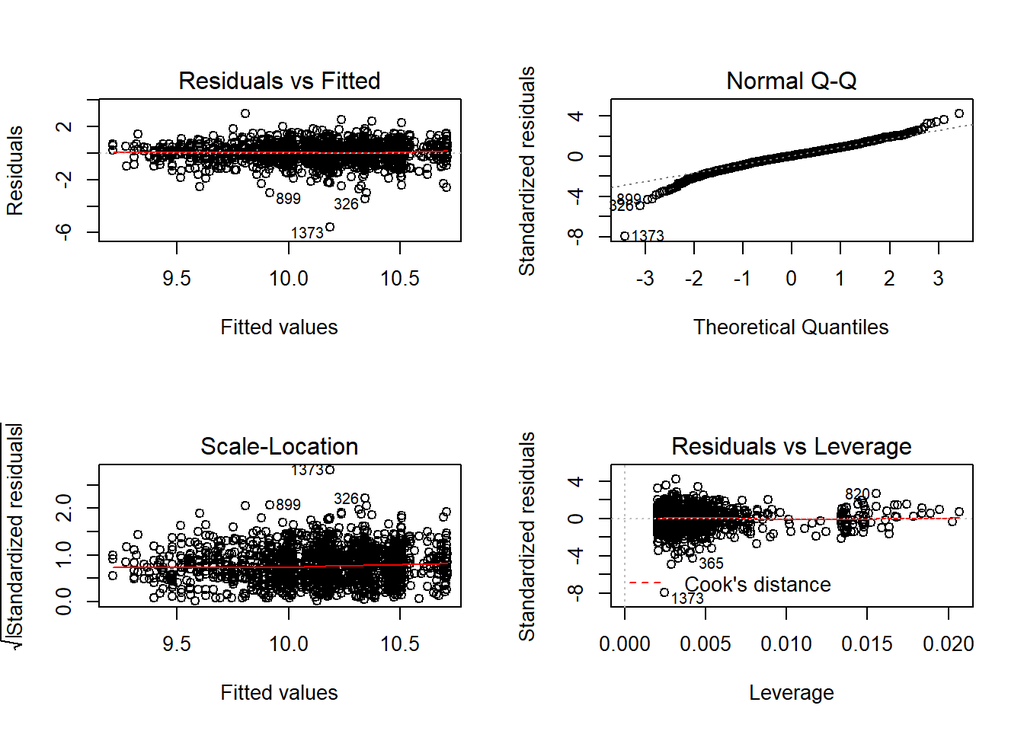

```r
par(mfrow = c(2, 2))
plot(model_04)
```

**Diagnostics of Model_04 Log Earnings**

**Breusch_Pagan Test**

- Since the p-value is > 0.05 we fail to reject the null hypothesis of homoskedasticity.

**Residuals vs Fitted Plot.**

- The line is horizonal and there is no distinct patterns, indicating a linear relationship.

**Normal Q-Q**

- The residuals seem to somewhat follow the dashed line, therefore it appears that the residuals are normally distributed.

**Scale-Location**

- Since the line is close to horizontal and based on our BP test we can see that we do not have a heteroscedasticity problem with this model.

# 5. Updates for the week4

**The updates in the week4’s report are:**

1. Following the professor’s comments from week3 and group’s new thoughts to revise the criteria of **earnings** - now it is bigger then $0.00
2. Build the models as in the section 4 above.